# Data Modeling

# Introduction

We are looking to explain the changing of certain states in the 2020 Election from Republican to Democratic. I am doing this with some variables I have calculated from Census data on migration from one state to another.

The following map is a good visualization of what we are trying to explain. We want to see if we can explain the purple states. However, we want to explain them in a way that we don’t get confused on why states didn’t switch sides.

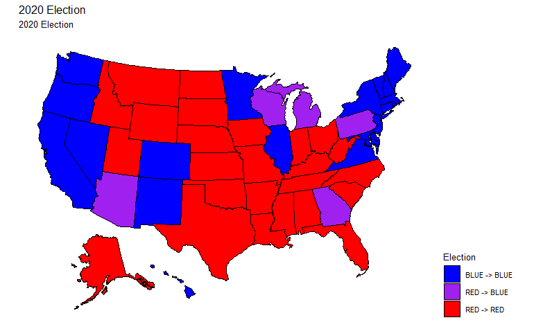

```r
plot_usmap(data = map_visualization, values = "difference", regions = "states") +
  scale_fill_manual(values = c("blue", "purple", "red"), name="Election") +
  labs(title = "2020 Election", subtitle = "2020 Election") +
  theme(legend.position = "right")
```

I have measured “skew” which is Democratic votes - Republic votes. So a positive number means democratic. I have the results from the 2016 and 2020 election.

Total migration is total migration for 2017, 2018, and 2019. 2020 was not available at the time of this analysis,but it was the year of COVID, so it is doubtful there was much migration. The total migration number is the sum of these three years with the total of migration from blue states (in 2016) minus the total migration from red states(2016). Once again a positive number means migration had more democratic state migration.

# Analysis

I looked at my variable of migration in relation to 2020 skew. This was to see if it could predict the skew of the 2020 election.

```r
migration_to_next_skew_model <- lm(skew2020 ~ totalMigration,
                                       data = ForStatisticalAnalysis)
```

```r
summary(migration_to_next_skew_model)
```

```
Call:
lm(formula = skew2020 ~ totalMigration, data = ForStatisticalAnalysis)

Residuals:
    Min      1Q  Median      3Q     Max
-772447 -339174 -219566  -20749 4694954

Coefficients:
                Estimate Std. Error t value Pr(>|t|)
(Intercept)    1.978e+05  1.174e+05   1.684  0.09845 .
totalMigration 2.683e+00  1.001e+00   2.681  0.00998 **
---
Signif. codes:  0 ‘***’ 0.001 ‘**’ 0.01 ‘*’ 0.05 ‘.’ 0.1 ‘ ’ 1

Residual standard error: 823500 on 49 degrees of freedom
Multiple R-squared:  0.1279,    Adjusted R-squared:  0.1101
F-statistic: 7.185 on 1 and 49 DF,  p-value: 0.009984
```

```r
effect("totalMigration", migration_to_next_skew_model) %>%
  data.frame() %>%  kable()
```

| totalMigration | fit | se | lower | upper |
| --- | --- | --- | --- | --- |
| -3e+05 | -606996.8 | 300998.4 | -1211875.73 | -2117.817 |
| -2e+05 | -338726.6 | 212049.2 | -764855.38 | 87402.156 |
| -2e+04 | 144159.7 | 115334.6 | -87613.85 | 375933.198 |
| 1e+05 | 466083.9 | 168080.6 | 128313.27 | 803854.460 |
| 2e+05 | 734354.0 | 250487.1 | 230981.44 | 1237726.613 |

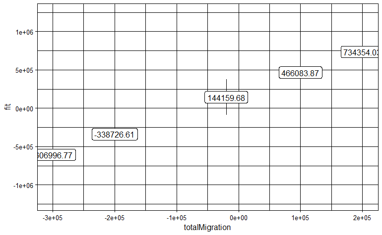

```r
effect("totalMigration", migration_to_next_skew_model) %>%
  data.frame() %>%
  ggplot(aes(x = totalMigration,
             y = fit,
             ymin = lower,
             ymax = upper,
             label = round(fit, digits = 2))) +
  geom_errorbar(width = .5) +
  geom_label() +
  theme_linedraw()
```